# py_sklearn_binaryclass_kaggle_tabular_playground_2021oct

### Binary Classification Model for Kaggle Tabular Playground Series October 2021 Using Python and Scikit-Learn

### November 15, 2021

Template Credit: Adapted from a template made available by Dr. Jason Brownlee of Machine Learning Mastery. [https://machinelearningmastery.com/]

SUMMARY: This project aims to construct a predictive model using various machine learning algorithms and document the end-to-end steps using a template. The Kaggle Tabular Playground October 2021 dataset is a binary classification situation where we attempt to predict one of the two possible outcomes.

INTRODUCTION: Kaggle wants to provide an approachable environment for relatively new people in their data science journey. Since January 2021, they have hosted playground-style competitions on Kaggle with fun but less complex, tabular datasets. The dataset used for this competition is synthetic but based on a real dataset and generated using a CTGAN. The original dataset deals with predicting the biological response of molecules given various chemical properties. Although the features are anonymized, they have properties relating to real-world features.

CONCLUSION: In this iteration, the Logistic Regression model appeared to be a suitable algorithm for modeling this dataset.

Dataset Used: Kaggle Tabular Playground 2021 October Data Set

Dataset ML Model: Binary classification with numerical and categorical attributes

Dataset Reference: https://www.kaggle.com/c/tabular-playground-series-oct-2021

One potential source of performance benchmark: https://www.kaggle.com/c/tabular-playground-series-oct-2021/leaderboard

Any predictive modeling machine learning project generally can be broken down into about six major tasks:

1. Prepare Environment
2. Summarize and Visualize Data
3. Pre-process Data
4. Train and Evaluate Models
5. Fine-tune and Improve Models
6. Finalize Model and Present Analysis

## Task 1 - Prepare Environment

```python
# Install the necessary packages for Colab
# !pip install python-dotenv PyMySQL
```

```python
# Retrieve the GPU information from Colab
# gpu_info = !nvidia-smi
# gpu_info = '\n'.join(gpu_info)
# if gpu_info.find('failed') >= 0:
#     print('Select the Runtime → "Change runtime type" menu to enable a GPU accelerator, ')
#     print('and then re-execute this cell.')
# else:
#     print(gpu_info)
```

```python
# Retrieve the memory configuration from Colab
# from psutil import virtual_memory
# ram_gb = virtual_memory().total / 1e9
# print('Your runtime has {:.1f} gigabytes of available RAM\n'.format(ram_gb))

# if ram_gb < 20:
#     print('To enable a high-RAM runtime, select the Runtime → "Change runtime type"')
#     print('menu, and then select High-RAM in the Runtime shape dropdown. Then, ')
#     print('re-execute this cell.')
# else:
#     print('You are using a high-RAM runtime!')
```

```python
# Retrieve the CPU information
ncpu = !nproc
print("The number of available CPUs is:", ncpu[0])
```

```
The number of available CPUs is: 4
```

### 1.a) Load libraries and modules

```python
# Set the random seed number for reproducible results
RNG_SEED = 888
```

```python
import numpy as np
import pandas as pd
import seaborn as sns
import matplotlib.pyplot as plt
import os
import sys
import math
from datetime import datetime
import boto3
from dotenv import load_dotenv
from sklearn import preprocessing
from sklearn.model_selection import train_test_split
from sklearn.model_selection import StratifiedKFold
from sklearn.model_selection import cross_val_score
from sklearn.model_selection import GridSearchCV
from sklearn.metrics import classification_report
from sklearn.metrics import confusion_matrix
from sklearn.metrics import accuracy_score
from sklearn.metrics import roc_auc_score
from sklearn.pipeline import Pipeline
from sklearn import compose
from sklearn import impute

from sklearn.linear_model import LogisticRegression
from sklearn.tree import DecisionTreeClassifier
from sklearn.neighbors import KNeighborsClassifier
from sklearn.ensemble import BaggingClassifier
from sklearn.ensemble import RandomForestClassifier
from sklearn.ensemble import ExtraTreesClassifier
from sklearn.ensemble import GradientBoostingClassifier
```

### 1.b) Set up the controlling parameters and functions

```python
# Begin the timer for the script processing
start_time_script = datetime.now()

# Set up the number of CPU cores available for multi-thread processing
N_JOBS = 1

# Set up the flag to stop sending progress emails (setting to True will send status emails!)
NOTIFY_STATUS = True

# Set the percentage sizes for splitting the dataset
TEST_SET_RATIO = 0.2
VAL_SET_RATIO = 0.25

# Set the number of folds for cross validation
N_FOLDS = 5

# Set various default modeling parameters
SCORING_METRIC = 'roc_auc'

# Define the directory locations and file names
TRAIN_DATASET = 'train.csv'
TEST_DATASET = 'test.csv'
```

```python
# Set up the email notification function
def status_notify(msg_text):
    access_key = os.environ.get('SNS_ACCESS_KEY')
    secret_key = os.environ.get('SNS_SECRET_KEY')
    aws_region = os.environ.get('SNS_AWS_REGION')
    topic_arn = os.environ.get('SNS_TOPIC_ARN')
    if (access_key is None) or (secret_key is None) or (aws_region is None):
        sys.exit("Incomplete notification setup info. Script Processing Aborted!!!")
    sns = boto3.client('sns', aws_access_key_id=access_key, aws_secret_access_key=secret_key, region_name=aws_region)
    response = sns.publish(TopicArn=topic_arn, Message=msg_text)
    if response['ResponseMetadata']['HTTPStatusCode'] != 200 :
        print('Status notification not OK with HTTP status code:', response['ResponseMetadata']['HTTPStatusCode'])
```

```python
if NOTIFY_STATUS: status_notify("Task 1 - Prepare Environment has begun! " + datetime.now().strftime('%a %B %d, %Y %I:%M:%S %p'))
```

### 1.c) Load dataset

```python
if not os.path.exists(TRAIN_DATASET):
    !wget https://dainesanalytics.com/datasets/kaggle-tabular-playground-2021oct/train.csv
```

```python
df_dataset_import = pd.read_csv(TRAIN_DATASET, index_col=False)

# Take a peek at the dataframe after import
print(df_dataset_import.head())
```

```
   id        f0        f1        f2        f3        f4        f5        f6  \
0   0  0.205979  0.410993  0.176775  0.223581  0.423543  0.476140  0.413590
1   1  0.181004  0.473119  0.011734  0.213657  0.619678  0.441593  0.230407
2   2  0.182583  0.307431  0.325950  0.207116  0.605699  0.309695  0.493337
3   3  0.180240  0.494592  0.008367  0.223580  0.760618  0.439211  0.432055
4   4  0.177172  0.495513  0.014263  0.548819  0.625396  0.562493  0.117158

         f7        f8  ...  f276  f277  f278  f279  f280  f281  f282  f283  \
0  0.612021  0.534873  ...     0     1     0     0     0     0     0     0
1  0.686013  0.281971  ...     0     1     0     0     0     0     0     0
2  0.751107  0.536272  ...     0     0     0     1     1     0     0     0
3  0.776147  0.483958  ...     0     0     0     0     1     0     0     0
4  0.561255  0.077115  ...     0     1     1     0     1     0     0     1

   f284  target
0     0       1
1     0       1
2     0       1
3     0       1
4     0       1

[5 rows x 287 columns]
```

```python
df_dataset_import.info(verbose=True)
```

```
<class 'pandas.core.frame.DataFrame'>
RangeIndex: 1000000 entries, 0 to 999999
Data columns (total 287 columns):
 #    Column  Dtype
---   ------  -----
 0    id      int64
 1    f0      float64
 2    f1      float64
 3    f2      float64
 4    f3      float64
 5    f4      float64
 6    f5      float64
 7    f6      float64
 8    f7      float64
 9    f8      float64
```

[output cut: 279 more lines]

```python
print(df_dataset_import.describe())
```

```
                   id              f0              f1              f2  \
count  1000000.000000  1000000.000000  1000000.000000  1000000.000000
mean    499999.500000        0.214334        0.460218        0.129253
std     288675.278932        0.053320        0.101316        0.120805
min          0.000000        0.041790        0.022016        0.000381
25%     249999.750000        0.181676        0.389215        0.017692
50%     499999.500000        0.204498        0.453893        0.095496
75%     749999.250000        0.229684        0.526023        0.177717
max     999999.000000        1.000000        0.959019        0.994818

                   f3              f4              f5              f6  \
count  1000000.000000  1000000.000000  1000000.000000  1000000.000000
mean         0.277598        0.580710        0.416619        0.386532
std          0.063163        0.115338        0.058231        0.133457
min          0.000000        0.000000        0.000959        0.000592
25%          0.235342        0.497938        0.374390        0.317815
50%          0.264669        0.565059        0.414009        0.420260
75%          0.305837        0.657024        0.458360        0.477140
max          0.979797        1.000000        0.907889        0.972601

                   f7              f8  ...            f276            f277  \
count  1000000.000000  1000000.000000  ...  1000000.000000  1000000.000000
mean         0.654858        0.462256  ...        0.250096        0.137164
std          0.065158        0.129439  ...        0.433068        0.344021
min          0.017994        0.000990  ...        0.000000        0.000000
25%          0.615372        0.363753  ...        0.000000        0.000000
50%          0.648562        0.475701  ...        0.000000        0.000000
75%          0.692666        0.561372  ...        1.000000        0.000000
max          0.986195        0.986118  ...        1.000000        1.000000

                 f278            f279            f280            f281  \
count  1000000.000000  1000000.000000  1000000.000000  1000000.000000
mean         0.144793        0.130667        0.139210        0.199331
std          0.351892        0.337036        0.346166        0.399498
min          0.000000        0.000000        0.000000        0.000000
25%          0.000000        0.000000        0.000000        0.000000
50%          0.000000        0.000000        0.000000        0.000000
75%          0.000000        0.000000        0.000000        0.000000
max          1.000000        1.000000        1.000000        1.000000

                 f282            f283           f284          target
count  1000000.000000  1000000.000000  1000000.00000  1000000.000000
mean         0.156065        0.183741        0.15468        0.500485
std          0.362917        0.387273        0.36160        0.500000
min          0.000000        0.000000        0.00000        0.000000
25%          0.000000        0.000000        0.00000        0.000000
50%          0.000000        0.000000        0.00000        1.000000
75%          0.000000        0.000000        0.00000        1.000000
max          1.000000        1.000000        1.00000        1.000000

[8 rows x 287 columns]
```

```python
print(df_dataset_import.isnull().sum())
print('Total number of NaN in the dataframe: ', df_dataset_import.isnull().sum().sum())
```

```
id        0
f0        0
f1        0
f2        0
f3        0
         ..
f281      0
f282      0
f283      0
f284      0
target    0
Length: 287, dtype: int64
Total number of NaN in the dataframe:  0
```

### 1.d) Data Cleaning

```python
# Dropping features
df_dataset_import.drop(columns=['id'], inplace=True)

# Take a peek at the dataframe after cleaning
print(df_dataset_import.head())
```

```
         f0        f1        f2        f3        f4        f5        f6  \
0  0.205979  0.410993  0.176775  0.223581  0.423543  0.476140  0.413590
1  0.181004  0.473119  0.011734  0.213657  0.619678  0.441593  0.230407
2  0.182583  0.307431  0.325950  0.207116  0.605699  0.309695  0.493337
3  0.180240  0.494592  0.008367  0.223580  0.760618  0.439211  0.432055
4  0.177172  0.495513  0.014263  0.548819  0.625396  0.562493  0.117158

         f7        f8        f9  ...  f276  f277  f278  f279  f280  f281  \
0  0.612021  0.534873  0.147295  ...     0     1     0     0     0     0
1  0.686013  0.281971  0.238509  ...     0     1     0     0     0     0
2  0.751107  0.536272  0.286813  ...     0     0     0     1     1     0
3  0.776147  0.483958  0.260886  ...     0     0     0     0     1     0
4  0.561255  0.077115  0.158321  ...     0     1     1     0     1     0

   f282  f283  f284  target
0     0     0     0       1
1     0     0     0       1
2     0     0     0       1
3     0     0     0       1
4     0     1     0       1

[5 rows x 286 columns]
```

```python
df_dataset_import.info(verbose=True)
```

```
<class 'pandas.core.frame.DataFrame'>
RangeIndex: 1000000 entries, 0 to 999999
Data columns (total 286 columns):
 #    Column  Dtype
---   ------  -----
 0    f0      float64
 1    f1      float64
 2    f2      float64
 3    f3      float64
 4    f4      float64
 5    f5      float64
 6    f6      float64
 7    f7      float64
 8    f8      float64
 9    f9      float64
```

[output cut: 278 more lines]

```python
print(df_dataset_import.describe())
```

```
                   f0              f1              f2              f3  \
count  1000000.000000  1000000.000000  1000000.000000  1000000.000000
mean         0.214334        0.460218        0.129253        0.277598
std          0.053320        0.101316        0.120805        0.063163
min          0.041790        0.022016        0.000381        0.000000
25%          0.181676        0.389215        0.017692        0.235342
50%          0.204498        0.453893        0.095496        0.264669
75%          0.229684        0.526023        0.177717        0.305837
max          1.000000        0.959019        0.994818        0.979797

                   f4              f5              f6              f7  \
count  1000000.000000  1000000.000000  1000000.000000  1000000.000000
mean         0.580710        0.416619        0.386532        0.654858
std          0.115338        0.058231        0.133457        0.065158
min          0.000000        0.000959        0.000592        0.017994
25%          0.497938        0.374390        0.317815        0.615372
50%          0.565059        0.414009        0.420260        0.648562
75%          0.657024        0.458360        0.477140        0.692666
max          1.000000        0.907889        0.972601        0.986195

                   f8              f9  ...            f276            f277  \
count  1000000.000000  1000000.000000  ...  1000000.000000  1000000.000000
mean         0.462256        0.258031  ...        0.250096        0.137164
std          0.129439        0.119081  ...        0.433068        0.344021
min          0.000990        0.051183  ...        0.000000        0.000000
25%          0.363753        0.164559  ...        0.000000        0.000000
50%          0.475701        0.227714  ...        0.000000        0.000000
75%          0.561372        0.300988  ...        1.000000        0.000000
max          0.986118        0.980994  ...        1.000000        1.000000

                 f278            f279            f280            f281  \
count  1000000.000000  1000000.000000  1000000.000000  1000000.000000
mean         0.144793        0.130667        0.139210        0.199331
std          0.351892        0.337036        0.346166        0.399498
min          0.000000        0.000000        0.000000        0.000000
25%          0.000000        0.000000        0.000000        0.000000
50%          0.000000        0.000000        0.000000        0.000000
75%          0.000000        0.000000        0.000000        0.000000
max          1.000000        1.000000        1.000000        1.000000

                 f282            f283           f284          target
count  1000000.000000  1000000.000000  1000000.00000  1000000.000000
mean         0.156065        0.183741        0.15468        0.500485
std          0.362917        0.387273        0.36160        0.500000
min          0.000000        0.000000        0.00000        0.000000
25%          0.000000        0.000000        0.00000        0.000000
50%          0.000000        0.000000        0.00000        1.000000
75%          0.000000        0.000000        0.00000        1.000000
max          1.000000        1.000000        1.00000        1.000000

[8 rows x 286 columns]
```

```python
print(df_dataset_import.isnull().sum())
print('Total number of NaN in the dataframe: ', df_dataset_import.isnull().sum().sum())
```

```
f0        0
f1        0
f2        0
f3        0
f4        0
         ..
f281      0
f282      0
f283      0
f284      0
target    0
Length: 286, dtype: int64
Total number of NaN in the dataframe:  0
```

### 1.e) Splitting Data into Sets

```python
# Use variable total_column_count to hold the number of columns in the dataframe
total_column_count = len(df_dataset_import.columns)

# Set up variable total_feature_count for the total number of attribute columns
total_feature_count = total_column_count-1

# We create attribute-only and target-only datasets (df_features_train and df_target_train)
df_target_train = df_dataset_import['target']
df_features_train = df_dataset_import.drop(['target'], axis=1)

print("df_dataset_import.shape: {} df_features_train.shape: {} df_target_train.shape: {}".format(df_dataset_import.shape, df_features_train.shape, df_target_train.shape))
```

```
df_dataset_import.shape: (1000000, 286) df_features_train.shape: (1000000, 285) df_target_train.shape: (1000000,)
```

### 1.f) Set up the parameters for data visualization

```python
# Set up the number of row and columns for visualization display. display_rows * display_columns should be >= total_feature_count
display_columns = 4
if total_feature_count % display_columns == 0 :
    display_rows = total_feature_count // display_columns
else :
    display_rows = (total_feature_count // display_columns) + 1

# Set figure width to display the data visualization plots
fig_size = plt.rcParams["figure.figsize"]
fig_size[0] = display_columns * 4
fig_size[1] = display_rows * 4
plt.rcParams["figure.figsize"] = fig_size
```

```python
if NOTIFY_STATUS: status_notify("Task 1 - Prepare Environment completed! "+datetime.now().strftime('%a %B %d, %Y %I:%M:%S %p'))
```

## Task 2 - Summarize and Visualize Data

```python
if NOTIFY_STATUS: status_notify("Task 2 - Summarize and Visualize Data has begun! "+datetime.now().strftime('%a %B %d, %Y %I:%M:%S %p'))
```

[figure not shown]

```python
# Histograms for each attribute
df_features_train.plot(kind='hist', subplots=True, layout=(display_rows, display_columns))
plt.show()
```

[figure not shown]

```python
# Box and Whisker plot for each attribute
df_features_train.plot(kind='box', subplots=True, layout=(display_rows, display_columns))
plt.show()
```

```python
# # Correlation matrix
# fig = plt.figure(figsize=(20,20))
# ax = fig.add_subplot(111)
# correlations = df_features_train.corr(method='pearson')
# cax = ax.matshow(correlations, vmin=-1, vmax=1)
# fig.colorbar(cax)
# plt.show()
```

```python
if NOTIFY_STATUS: status_notify("Task 2 - Summarize and Visualize Data completed! "+datetime.now().strftime('%a %B %d, %Y %I:%M:%S %p'))
```

## Task 3 - Pre-process Data

```python
if NOTIFY_STATUS: status_notify("Task 3 - Pre-process Data has begun! "+datetime.now().strftime('%a %B %d, %Y %I:%M:%S %p'))
```

### 3.a) Splitting Data into Training and Test Sets

```python
# Not applicable for this iteration of the project
```

### 3.b) Feature Scaling and Data Pre-Processing

```python
# Compose pipeline for the numerical and categorical features (Block #1 of 2)
numeric_columns = df_features_train.select_dtypes(include=['float64']).columns
numeric_transformer = Pipeline(steps=[
#     ('imputer', impute.SimpleImputer(strategy="constant", fill_value=0)),
    ('scaler', preprocessing.MinMaxScaler())
])
categorical_columns = df_features_train.select_dtypes(include=['int64','object','bool','category']).columns
categorical_transformer = Pipeline(steps=[
#     ('imputer', impute.SimpleImputer(strategy='constant', fill_value='UKNOWN')),
    ('onehot', preprocessing.OneHotEncoder(sparse=False, handle_unknown='ignore'))
])

print("Number of numerical columns:", len(numeric_columns))
print("Number of categorical columns:", len(categorical_columns))
print("Total number of columns in the feature dataframe:", df_features_train.shape[1])
```

```
Number of numerical columns: 240
Number of categorical columns: 45
Total number of columns in the feature dataframe: 285
```

```python
# Compose pipeline for the numerical and categorical features (Block #2 of 2)
preprocessor = compose.ColumnTransformer(transformers=[
    ('num', numeric_transformer, numeric_columns),
    ('cat', categorical_transformer, categorical_columns)
])

# Display the shapes of the training dataset for final inspection
array_features_train = preprocessor.fit_transform(df_features_train)
print("Transformed features from df_features_train.shape: {} to array_features_train.shape: {}".format(df_features_train.shape, array_features_train.shape))
```

```
Transformed features from df_features_train.shape: (1000000, 285) to array_features_train.shape: (1000000, 330)
```

### 3.c) Training Data Balancing

```python
# Not applicable for this iteration of the project
```

### 3.d) Feature Selection

```python
# Not applicable for this iteration of the project
```

### 3.e) Display the Final Datasets for Model-Building

```python
# Finalize the training and validation datasets for the modeling activities
# array_features_train = df_features_train.to_numpy()
array_target_train = df_target_train.ravel()
print("array_features_train.shape: {} array_target_train.shape: {}".format(array_features_train.shape, array_target_train.shape))
```

```
array_features_train.shape: (1000000, 330) array_target_train.shape: (1000000,)
```

```python
if NOTIFY_STATUS: status_notify("Task 3 - Pre-process Data completed! "+datetime.now().strftime('%a %B %d, %Y %I:%M:%S %p'))
```

## Task 4 - Train and Evaluate Models

```python
if NOTIFY_STATUS: status_notify("Task 4 - Train and Evaluate Models has begun! "+datetime.now().strftime('%a %B %d, %Y %I:%M:%S %p'))
```

### 4.a) Set test options and evaluation metric

```python
# Set up Algorithms Spot-Checking Array
start_time_training = datetime.now()
start_time_module = datetime.now()
train_models = []
train_results = []
train_model_names = []
train_metrics = []
train_models.append(('LGR', LogisticRegression(random_state=RNG_SEED, n_jobs=N_JOBS)))
train_models.append(('CART', DecisionTreeClassifier(random_state=RNG_SEED)))
train_models.append(('KNN', KNeighborsClassifier(n_jobs=N_JOBS)))
train_models.append(('BGT', BaggingClassifier(random_state=RNG_SEED, n_jobs=N_JOBS)))
train_models.append(('RNF', RandomForestClassifier(random_state=RNG_SEED, n_jobs=N_JOBS)))
train_models.append(('EXT', ExtraTreesClassifier(random_state=RNG_SEED, n_jobs=N_JOBS)))
```

```python
# Generate model in turn
for name, model in train_models:
	if NOTIFY_STATUS: status_notify("Algorithm "+name+" modeling has begun! "+datetime.now().strftime('%a %B %d, %Y %I:%M:%S %p'))
	start_time_module = datetime.now()
	kfold = StratifiedKFold(n_splits=N_FOLDS, shuffle=True, random_state=RNG_SEED)
	cv_results = cross_val_score(model, array_features_train, array_target_train, cv=kfold, scoring=SCORING_METRIC, n_jobs=N_JOBS, verbose=1)
	train_results.append(cv_results)
	train_model_names.append(name)
	train_metrics.append(cv_results.mean())
	print("%s: %f (%f)" % (name, cv_results.mean(), cv_results.std()))
	print(model)
	print ('Model training time:', (datetime.now() - start_time_module), '\n')
	if NOTIFY_STATUS: status_notify("Algorithm "+name+" modeling completed! "+datetime.now().strftime('%a %B %d, %Y %I:%M:%S %p'))
print ('Average metrics ('+SCORING_METRIC+') from all models:',np.mean(train_metrics))
print ('Total training time for all models:',(datetime.now() - start_time_training))
```

[output not shown]

```
LGR: 0.839784 (0.000902)
LogisticRegression(n_jobs=1, random_state=888)
Model training time: 0:02:06.126674
```

```
[Parallel(n_jobs=1)]: Using backend SequentialBackend with 1 concurrent workers.
[Parallel(n_jobs=1)]: Done   5 out of   5 | elapsed: 63.4min finished
```

```
CART: 0.666813 (0.000667)
DecisionTreeClassifier(random_state=888)
Model training time: 1:03:26.457932
```

```
[Parallel(n_jobs=1)]: Using backend SequentialBackend with 1 concurrent workers.
[Parallel(n_jobs=1)]: Done   5 out of   5 | elapsed: 345.6min finished
```

```
KNN: 0.705837 (0.000454)
KNeighborsClassifier(n_jobs=1)
Model training time: 5:45:36.931803
```

```
[Parallel(n_jobs=1)]: Using backend SequentialBackend with 1 concurrent workers.
[Parallel(n_jobs=1)]: Done   5 out of   5 | elapsed: 431.6min finished
```

```
BGT: 0.803438 (0.001013)
BaggingClassifier(n_jobs=1, random_state=888)
Model training time: 7:11:35.613581
```

```
[Parallel(n_jobs=1)]: Using backend SequentialBackend with 1 concurrent workers.
[Parallel(n_jobs=1)]: Done   5 out of   5 | elapsed: 186.0min finished
```

```
RNF: 0.831848 (0.000844)
RandomForestClassifier(n_jobs=1, random_state=888)
Model training time: 3:05:59.449508
```

```
[Parallel(n_jobs=1)]: Using backend SequentialBackend with 1 concurrent workers.
[Parallel(n_jobs=1)]: Done   5 out of   5 | elapsed: 63.5min finished
```

```
EXT: 0.812684 (0.000988)
ExtraTreesClassifier(n_jobs=1, random_state=888)
Model training time: 1:03:31.085324

Average metrics (roc_auc) from all models: 0.7767339813540031
Total training time for all models: 18:12:22.353608
```

### 4.b) Spot-checking baseline algorithms

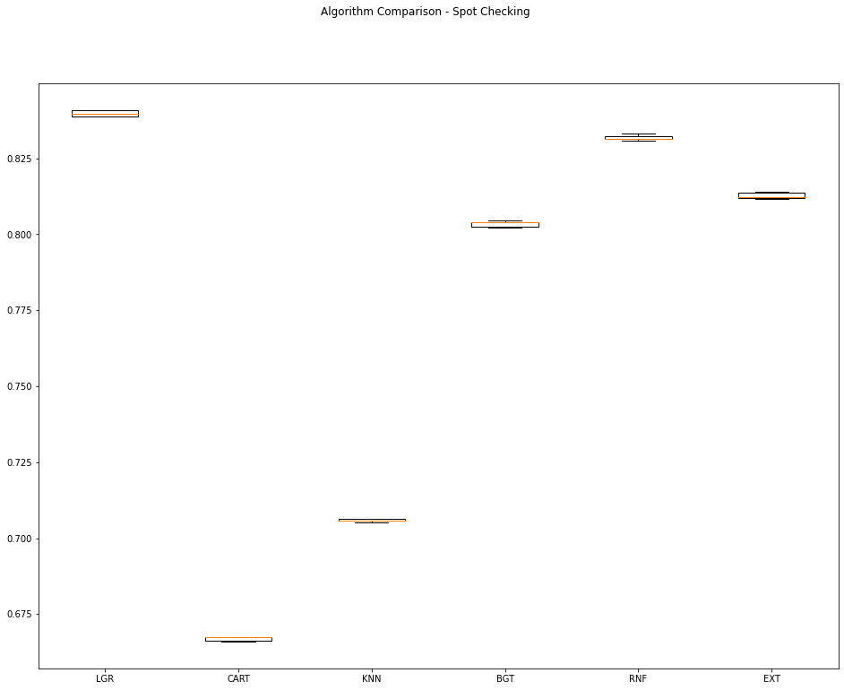

```python
fig = plt.figure(figsize=(16,12))
fig.suptitle('Algorithm Comparison - Spot Checking')
ax = fig.add_subplot(111)
plt.boxplot(train_results)
ax.set_xticklabels(train_model_names)
plt.show()
```

```python
if NOTIFY_STATUS: status_notify("Task 4 - Train and Evaluate Models completed! "+datetime.now().strftime('%a %B %d, %Y %I:%M:%S %p'))
```

## Task 5 - Fine-tune and Improve Models

```python
if NOTIFY_STATUS: status_notify("Task 5 - Fine-tune and Improve Models has begun! "+datetime.now().strftime('%a %B %d, %Y %I:%M:%S %p'))
```

### 5.a) Algorithm Tuning

```python
# Set up the comparison array
tune_results = []
tune_model_names = []
```

```python
# Tuning algorithm #1 - Logistic Regression
start_time_module = datetime.now()
if NOTIFY_STATUS: status_notify("Algorithm #1 tuning has begun! "+datetime.now().strftime('%a %B %d, %Y %I:%M:%S %p'))

tune_model1 = LogisticRegression(random_state=RNG_SEED, n_jobs=N_JOBS)
tune_model_names.append('LGR')
paramGrid1 = dict(solver=np.array(['lbfgs','sag','saga']))

kfold = StratifiedKFold(n_splits=N_FOLDS, shuffle=True, random_state=RNG_SEED)
grid1 = GridSearchCV(estimator=tune_model1, param_grid=paramGrid1, scoring=SCORING_METRIC, cv=kfold, n_jobs=N_JOBS, verbose=1)
grid_result1 = grid1.fit(array_features_train, array_target_train)

print("Best: %f using %s" % (grid_result1.best_score_, grid_result1.best_params_))
tune_results.append(grid_result1.cv_results_['mean_test_score'])
means = grid_result1.cv_results_['mean_test_score']
stds = grid_result1.cv_results_['std_test_score']
params = grid_result1.cv_results_['params']
for mean, stdev, param in zip(means, stds, params):
    print("%f (%f) with: %r" % (mean, stdev, param))
print ('Model training time:',(datetime.now() - start_time_module))
if NOTIFY_STATUS: status_notify("Algorithm #1 tuning completed! "+datetime.now().strftime('%a %B %d, %Y %I:%M:%S %p'))
```

```
Fitting 5 folds for each of 3 candidates, totalling 15 fits
```

[output not shown]

```
Best: 0.839793 using {'solver': 'saga'}
0.839784 (0.000902) with: {'solver': 'lbfgs'}
0.839793 (0.000900) with: {'solver': 'sag'}
0.839793 (0.000900) with: {'solver': 'saga'}
Model training time: 0:24:48.146628
```

### 5.b) Compare Algorithms After Tuning

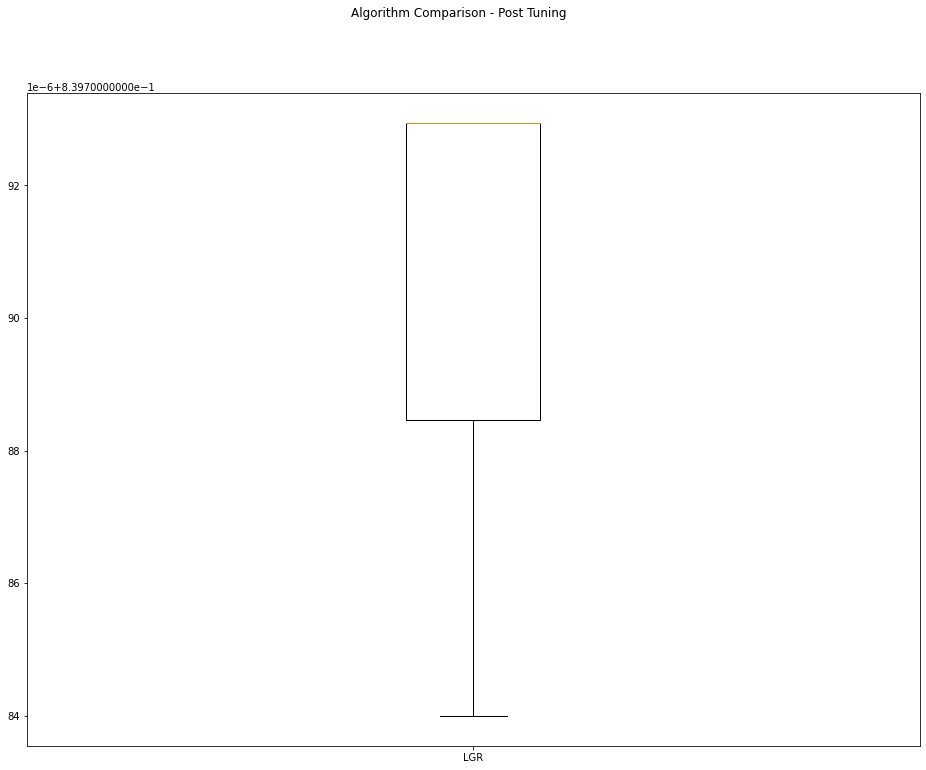

```python
fig = plt.figure(figsize=(16,12))
fig.suptitle('Algorithm Comparison - Post Tuning')
ax = fig.add_subplot(111)
plt.boxplot(tune_results)
ax.set_xticklabels(tune_model_names)
plt.show()
```

```python
if NOTIFY_STATUS: status_notify("Task 5 - Fine-tune and Improve Models completed! "+datetime.now().strftime('%a %B %d, %Y %I:%M:%S %p'))
```

## Task 6 - Finalize Model and Present Analysis

```python
if NOTIFY_STATUS: status_notify("Task 6 - Finalize Model and Present Analysis has begun! "+datetime.now().strftime('%a %B %d, %Y %I:%M:%S %p'))
```

### 6.a) Train the Final Model

```python
final_model = LogisticRegression(random_state=RNG_SEED, n_jobs=N_JOBS, solver='saga')
final_model.fit(array_features_train, array_target_train)
print(final_model)
```

```
LogisticRegression(n_jobs=1, random_state=888, solver='saga')
```

### 6.b) Load Test Dataset and Prepare the Submission File

```python
if not os.path.exists(TEST_DATASET):
    !wget https://dainesanalytics.com/datasets/kaggle-tabular-playground-2021oct/test.csv
```

```
--2021-11-14 18:19:59--  https://dainesanalytics.com/datasets/kaggle-tabular-playground-2021oct/test.csv
Resolving dainesanalytics.com (dainesanalytics.com)... 13.226.230.79, 13.226.230.77, 13.226.230.91, ...
Connecting to dainesanalytics.com (dainesanalytics.com)|13.226.230.79|:443... connected.
HTTP request sent, awaiting response... 200 OK
Length: 1162300847 (1.1G) [text/csv]
Saving to: ‘test.csv’

test.csv            100%[===================>]   1.08G  5.70MB/s    in 3m 17s

2021-11-14 18:23:16 (5.62 MB/s) - ‘test.csv’ saved [1162300847/1162300847]
```

```python
df_features_test = pd.read_csv(TEST_DATASET, index_col=False)

# Take a peek at the dataframe after import
print(df_features_test.head())
```

```
        id        f0        f1        f2        f3        f4        f5  \
0  1000000  0.178216  0.435617  0.010230  0.202074  0.390170  0.324221
1  1000001  0.181250  0.476455  0.022413  0.283146  0.598020  0.349508
2  1000002  0.159721  0.451202  0.259649  0.365274  0.594634  0.413502
3  1000003  0.182424  0.520976  0.095344  0.327742  0.741830  0.358711
4  1000004  0.229329  0.336513  0.023511  0.300913  0.668738  0.481586

         f6        f7        f8  ...  f275  f276  f277  f278  f279  f280  \
0  0.221722  0.738894  0.582588  ...     1     0     0     0     0     0
1  0.283467  0.721575  0.268990  ...     0     0     0     0     0     0
2  0.249318  0.642339  0.411104  ...     0     0     0     0     0     0
3  0.270077  0.601662  0.297742  ...     0     0     0     0     0     1
4  0.545660  0.667849  0.546045  ...     0     0     0     0     1     0

   f281  f282  f283  f284
0     1     1     1     0
1     0     0     0     0
2     1     0     0     0
3     1     0     0     0
4     0     1     0     0

[5 rows x 286 columns]
```

```python
df_kaggle_submission = pd.DataFrame()
df_kaggle_submission['id'] = df_features_test['id']
print(df_kaggle_submission.head())
```

```
        id
0  1000000
1  1000001
2  1000002
3  1000003
4  1000004
```

```python
# Dropping features
df_features_test.drop(columns=['id'], inplace=True)

# Take a peek at the dataframe after cleaning
print(df_features_test.head())
```

```
         f0        f1        f2        f3        f4        f5        f6  \
0  0.178216  0.435617  0.010230  0.202074  0.390170  0.324221  0.221722
1  0.181250  0.476455  0.022413  0.283146  0.598020  0.349508  0.283467
2  0.159721  0.451202  0.259649  0.365274  0.594634  0.413502  0.249318
3  0.182424  0.520976  0.095344  0.327742  0.741830  0.358711  0.270077
4  0.229329  0.336513  0.023511  0.300913  0.668738  0.481586  0.545660

         f7        f8        f9  ...  f275  f276  f277  f278  f279  f280  \
0  0.738894  0.582588  0.343770  ...     1     0     0     0     0     0
1  0.721575  0.268990  0.208373  ...     0     0     0     0     0     0
2  0.642339  0.411104  0.246891  ...     0     0     0     0     0     0
3  0.601662  0.297742  0.252829  ...     0     0     0     0     0     1
4  0.667849  0.546045  0.202731  ...     0     0     0     0     1     0

   f281  f282  f283  f284
0     1     1     1     0
1     0     0     0     0
2     1     0     0     0
3     1     0     0     0
4     0     1     0     0

[5 rows x 285 columns]
```

```python
# Finalize the test dataset for the modeling testing
array_features_test = preprocessor.transform(df_features_test)
print("Transformed features from df_features_test.shape: {} to array_features_test.shape: {}".format(df_features_test.shape, array_features_test.shape))
```

```
Transformed features from df_features_test.shape: (500000, 285) to array_features_test.shape: (500000, 330)
```

```python
# Make batched predictions
test_predictions = final_model.predict_proba(array_features_test)[:,1]
print(test_predictions)
```

```
[0.62563372 0.34365068 0.87582039 ... 0.2062912  0.60574027 0.28997213]
```

```python
df_kaggle_submission['target'] = test_predictions
print(df_kaggle_submission.head())
```

```
        id    target
0  1000000  0.625634
1  1000001  0.343651
2  1000002  0.875820
3  1000003  0.800466
4  1000004  0.284752
```

```python
submission_file = df_kaggle_submission.to_csv(header=True, index=False)
filename = 'submission_' + datetime.now().strftime('%Y%m%d-%H%M') + '.csv'
with open(filename, 'w') as f:
    f.write(submission_file)
    print('Completed writing output file: ' + filename)
```

```
Completed writing output file: submission_20211114-1827.csv
```

```python
if NOTIFY_STATUS: status_notify("Task 6 - Finalize Model and Present Analysis completed! "+datetime.now().strftime('%a %B %d, %Y %I:%M:%S %p'))
```

```python
print ('Total time for the script:',(datetime.now() - start_time_script))
```

```
Total time for the script: 1 day, 4:43:01.474638
```